# R Notebook

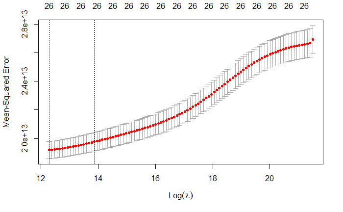

```r
plot(cv_ridge)
```

```r
cv_ridge$lambda.min
```

```
[1] 216221.5
```

```r
cv_ridge$lambda.1se
```

```
[1] 1051399
```

```r
lbs_fun <- function(fit, offset_x=1, ...) {
  L <- length(fit$lambda)
  x <- log(fit$lambda[L]) + offset_x
  y <- fit$beta[ ,L]
  labs <- names(y)
  text(x, y, labels=labs, ...)
}

plot(ridge, xvar = "lambda", label=T)
lbs_fun(ridge) # add namnes
```

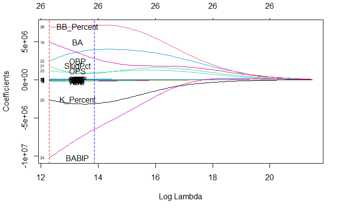

```r
abline(v = log(cv_ridge$lambda.min), col = "red", lty=2) #lambda.min
abline(v = log(cv_ridge$lambda.1se), col="blue", lty=2)  #lambda.1se
```

```r
min_ridge <- glmnet(x_var, y_var, alpha=0, lambda = cv_ridge$lambda.min)
coef(min_ridge)
```

```
27 x 1 sparse Matrix of class "dgCMatrix"
                      s0
(Intercept)  3250721.298
G             -58444.324
AB              6525.990
R              18080.066
H              13278.220
X2B           -69523.006
X3B          -242522.624
HR            -18087.206
RBI            13495.290
SB             36983.072
CS           -135994.183
BB             21055.638
SO              5972.853
IBB            85143.276
HBP           -15492.692
SH           -240184.732
SF             25292.413
GIDP           96266.785
BA           4307633.443
PA              5100.777
TB              1191.386
SlugPct      1694540.697
OBP          2293477.173
OPS          1307566.357
BABIP       -9978065.658
K_Percent   -2726576.999
BB_Percent   7042279.208
```

```r
# Make predictions on the test data
predictions <- min_ridge %>% predict(x_var) %>% as.vector()

# Model performance metrics
data.frame(
  RMSE = RMSE(predictions, y_var),
  Rsquare = R2(predictions, y_var)
)
```

| RMSE | Rsquare |
| --- | --- |
| 4355064 | 0.296666 |

```r
# Lasso

# getting the predictors
x_var <- bstats_salary_numvars %>% select(-salary) %>% as.matrix()
# getting the independent variable
y_var <- bstats_salary_numvars[,"salary"]
```

```r
lasso <- glmnet(x_var, y_var, alpha=1)
summary(lasso)
```

```
          Length Class     Mode
a0          93   -none-    numeric
beta      2418   dgCMatrix S4
df          93   -none-    numeric
dim          2   -none-    numeric
lambda      93   -none-    numeric
dev.ratio   93   -none-    numeric
nulldev      1   -none-    numeric
npasses      1   -none-    numeric
jerr         1   -none-    numeric
offset       1   -none-    logical
call         4   -none-    call
nobs         1   -none-    numeric
```

```r
cv_lasso <- cv.glmnet(x_var, y_var, alpha = 1)
cv_lasso
```

```
Call:  cv.glmnet(x = x_var, y = y_var, alpha = 1)

Measure: Mean-Squared Error

    Lambda Index   Measure        SE Nonzero
min   4245    68 1.899e+13 6.269e+11      20
1se  91445    35 1.956e+13 6.738e+11      17
```

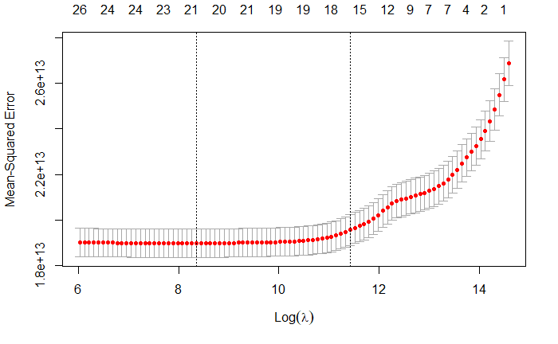

```r
plot(cv_lasso)
```

```r
lbs_fun <- function(fit, offset_x=1, ...) {
  L <- length(fit$lambda)
  x <- log(fit$lambda[L])+ offset_x
  y <- fit$beta[, L]
  labs <- names(y)
  text(x, y, labels=labs, ...)
}
plot(lasso, xvar = "lambda", label=T)
lbs_fun(lasso)
```

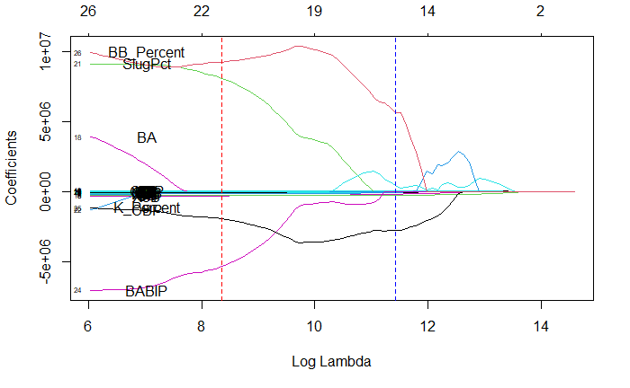

```r
abline(v=log(cv_lasso$lambda.min), col = "red", lty=2)
abline(v=log(cv_lasso$lambda.1se), col="blue", lty=2)
```

```r
min_lasso <- glmnet(x_var, y_var, alpha=1, lambda = cv_lasso$lambda.min)
coef(min_lasso)
```

```
27 x 1 sparse Matrix of class "dgCMatrix"
                      s0
(Intercept)  2264368.199
G             -87629.654
AB             24232.612
R              18771.351
H                  .
X2B          -107459.897
X3B          -280673.479
HR            -57743.509
RBI            20863.414
SB             33703.191
CS           -150540.856
BB             28671.666
SO                 .
IBB            99202.779
HBP            -8281.984
SH           -238325.444
SF             19061.264
GIDP           87321.414
BA                 .
PA              1860.331
TB             -1044.547
SlugPct      4865101.358
OBP                .
OPS          2765165.903
BABIP       -6624249.070
K_Percent   -1340986.372
BB_Percent   7490373.836
```

```r
se_lasso <- glmnet(x_var, y_var, alpha=1, lambda = cv_lasso$lambda.1se)
coef(se_lasso)
```

```
27 x 1 sparse Matrix of class "dgCMatrix"
                      s0
(Intercept)  3242070.189
G             -50386.031
AB              9548.952
R              12602.471
H                  .
X2B            -8338.434
X3B          -168194.535
HR              9621.891
RBI            15185.753
SB              4485.584
CS            -39631.941
BB             29452.924
SO                 .
IBB            83501.590
HBP                .
SH           -218512.738
SF                 .
GIDP           86598.503
BA                 .
PA              1625.492
TB                 .
SlugPct            .
OBP                .
OPS           477409.136
BABIP              .
K_Percent   -2789571.448
BB_Percent   5662137.375
```

```r
# Make predictions on the test data
predictions <- min_lasso %>% predict(x_var) %>% as.vector()
# Model performance metrics
data.frame(
  RMSE = RMSE(predictions, y_var),
  Rsquare = R2(predictions, y_var)
)
```

| RMSE | Rsquare |
| --- | --- |
| 4329508 | 0.3040184 |

## Salary Data

```r
franchise <- c(`ANA` = "LAA", `ARI` = "ARI", `ATL` = "ATL",
               `BAL` = "BAL", `BOS` = "BOS", `CAL` = "LAA",
               `CHA` = "CHA", `CHN` = "CHN", `CIN` = "CIN",
               `CLE` = "CLE", `COL` = "COL", `DET` = "DET",
               `FLO` = "MIA", `HOU` = "HOU", `KCA` = "KCA",
               `LAA` = "LAA", `LAN` = "LAN", `MIA` = "MIA",
               `MIL` = "MIL", `MIN` = "MIN", `ML4` = "MIL",
               `MON` = "WAS", `NYA` = "NYA", `NYM` = "NYN",
               `NYN` = "NYN", `OAK` = "OAK", `PHI` = "PHI",
               `PIT` = "PIT", `SDN` = "SDN", `SEA` = "SEA",
               `SFG` = "SFN", `SFN` = "SFN", `SLN` = "SLN",
               `TBA` = "TBA", `TEX` = "TEX", `TOR` = "TOR",
               `WAS` = "WAS")
```

```r
Salaries$franchise <- unname(franchise[Salaries$teamID])
```

```r
avg_team_salaries <- Salaries %>%
    group_by(yearID, franchise, lgID) %>%
    summarise(salary = mean(salary)/1e6) %>%
    filter(!(franchise == "CLE" & lgID == "NL"))
```

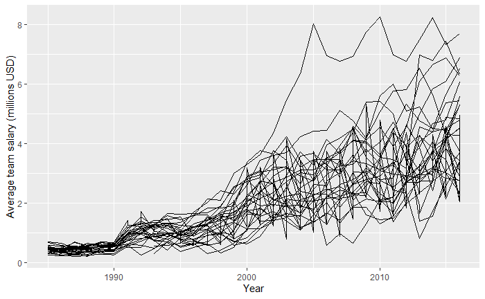

```r
ggplot(avg_team_salaries,
       aes(x = yearID, y = salary, group = factor(franchise))) +
       geom_path() +
       labs(x = "Year", y = "Average team salary (millions USD)")
```

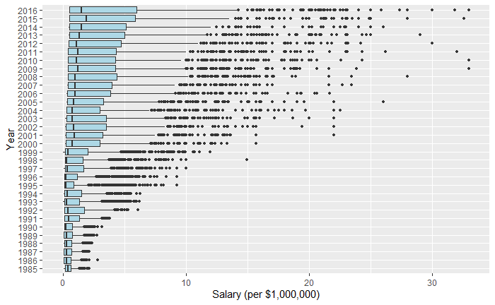

```r
ggplot(Salaries, aes(x = factor(yearID), y = salary/1e6)) +
   geom_boxplot(fill = "lightblue", outlier.size = 1) +
   labs(x = "Year", y = "Salary (per $1,000,000)") +
   coord_flip()
```

```r
avg_team_salaries1 <- Salaries %>%
    group_by(yearID, franchise, lgID) %>%
    summarise(salary= mean(salary)/1e6) %>%
    filter(!(franchise == "CLE" & lgID == "NL")) %>%
    filter(yearID >= 2002)
avg_team_salaries1 %>%
  arrange(desc(salary))
```

| yearID | franchise | lgID | salary |
| --- | --- | --- | --- |
| 2010 | NYA | AL | 8.2533356 |
| 2014 | NYA | AL | 8.2309961 |
| 2005 | NYA | AL | 8.0118007 |
| 2009 | NYA | AL | 7.7480457 |
| 2016 | NYA | AL | 7.6895790 |
| 2013 | NYA | AL | 7.4831899 |
| 2015 | LAN | NL | 7.4411034 |
| 2015 | NYA | AL | 7.3362744 |
| 2013 | LAN | NL | 6.9800686 |
| 2011 | NYA | AL | 6.9750010 |

[output cut: 440 more lines]

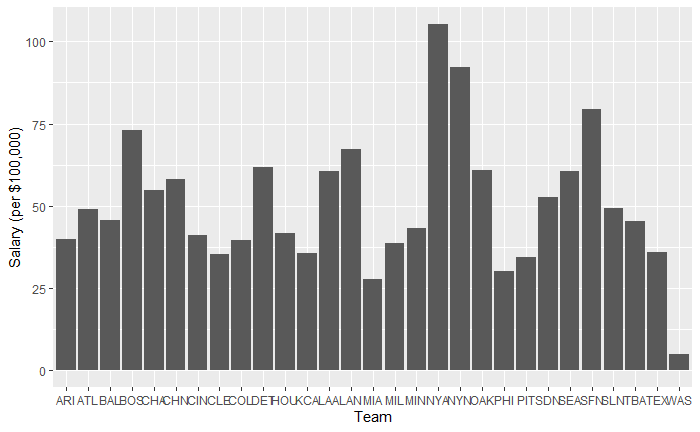

```r
ggplot(avg_team_salaries1, aes(x = franchise, y = salary)) +
  geom_bar(stat = "identity") +
  labs(x = "Team", y = "Salary (per $100,000)")
```

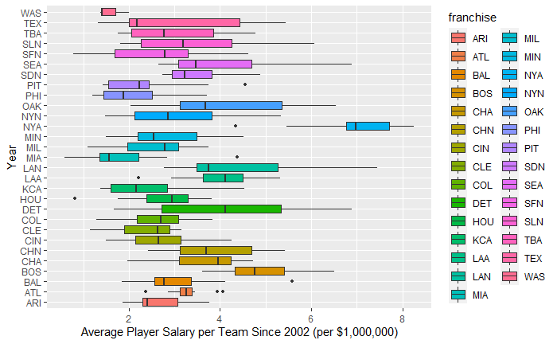

```r
ggplot(avg_team_salaries1, aes(x = franchise, y = salary, fill = franchise)) +
   geom_boxplot(outlier.size = 1) +
   labs(x = "Year", y = "Average Player Salary per Team Since 2002 (per $1,000,000)") +
   coord_flip()
```

```r
career_Babe <- bstats %>%
  select(playerID, yearID, HR) %>%
  filter(yearID > 1919 & yearID < 1935)

#career_Babe %>%
  #group_by(playerID) %>%
 # transmute(Total = sum(HR)) %>%
 # arrange(desc(Total))

transform(career_Babe, Total= ave(HR, playerID, FUN=sum))[-2]
```

| playerID | HR | Total |
| --- | --- | --- |
| acostjo01 | 0 | 0 |
| adamsba01 | 1 | 2 |
| ainsmed01 | 1 | 17 |
| alexape01 | 1 | 7 |
| allenni01 | 0 | 0 |
| altener01 | 0 | 0 |
| austiji01 | 1 | 1 |
| ayersdo01 | 0 | 0 |
| bagbyji01 | 1 | 1 |
| bailege01 | 0 | 2 |

[output cut: 990 more lines]

```r
career_Babe <- career_Babe %>%
  group_by(playerID) %>%
  summarize(HR = sum(HR)) %>%
  arrange(desc(HR)) %>%
  head(10)
```

```r
career_Babe$playerID[career_Babe$playerID == "ruthba01"] <- "Babe Ruth"
career_Babe$playerID[career_Babe$playerID == "gehrilo01"] <- "Lou Gehrig"
career_Babe$playerID[career_Babe$playerID == "hornsro01"] <- "Rogers Hornsby"
career_Babe$playerID[career_Babe$playerID == "foxxji01"] <- "Jimmie Foxx"
career_Babe$playerID[career_Babe$playerID == "wilsoha01"] <- "Hack Wilson"
career_Babe$playerID[career_Babe$playerID == "simmoal01"] <- "Al Simmons"
career_Babe$playerID[career_Babe$playerID == "kleinch01"] <- "Chuck Klein"
career_Babe$playerID[career_Babe$playerID == "ottme01"] <- "Mel Ott"
career_Babe$playerID[career_Babe$playerID == "gosligo01"] <- "Goose Goslin"
career_Babe$playerID[career_Babe$playerID == "bottoji01"] <- "Jim Bottomley"
```

```r
career_Babe
```

| playerID | HR |
| --- | --- |
| Babe Ruth | 659 |
| Lou Gehrig | 348 |
| Rogers Hornsby | 273 |
| Jimmie Foxx | 266 |
| Hack Wilson | 244 |
| Al Simmons | 240 |
| Chuck Klein | 211 |
| Mel Ott | 211 |
| Goose Goslin | 209 |
| Jim Bottomley | 205 |

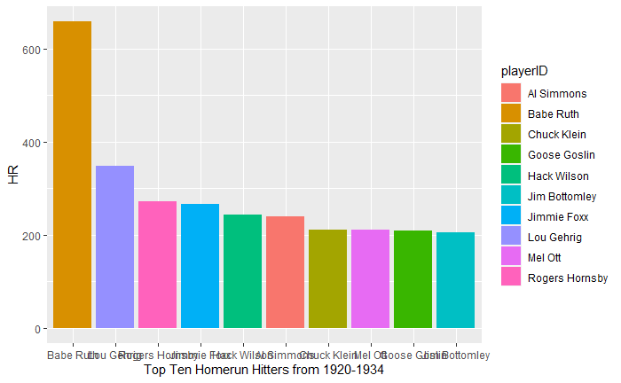

```r
ggplot(data = career_Babe, aes(x = reorder(playerID, -HR), y = HR, fill = playerID)) +
  geom_bar(stat = "identity") +
  labs(x = "Top Ten Homerun Hitters from 1920-1934")
```

```r
salary_batting <- bstats %>%
              filter(yearID >= 1985) %>%
              left_join(select(Salaries, playerID, yearID, teamID, salary),
                         by=c("playerID", "yearID", "teamID"))
str(salary_batting)
```

```
'data.frame':   46535 obs. of  32 variables:
 $ playerID  : chr  "aasedo01" "abregjo01" "ackerji01" "adamsri02" ...
 $ yearID    : num  1985 1985 1985 1985 1985 ...
 $ stint     : num  1 1 1 1 1 1 1 1 1 1 ...
 $ teamID    : Factor w/ 149 levels "ALT","ANA","ARI",..: 5 35 134 117 33 102 94 134 134 134 ...
 $ lgID      : Factor w/ 7 levels "AA","AL","FL",..: 2 5 2 5 2 5 5 2 2 2 ...
 $ G         : num  54 6 61 54 54 91 22 12 36 14 ...
 $ AB        : num  0 9 0 121 0 165 36 20 0 34 ...
 $ R         : num  0 0 0 12 0 27 1 2 0 2 ...
 $ H         : num  0 0 0 23 0 46 10 4 0 4 ...
 $ X2B       : num  0 0 0 3 0 7 2 1 0 1 ...
 $ X3B       : num  0 0 0 1 0 3 0 0 0 0 ...
 $ HR        : num  0 0 0 2 0 6 0 1 0 0 ...
 $ RBI       : num  0 1 0 10 0 21 2 5 0 3 ...
 $ SB        : num  0 0 0 1 0 1 0 0 0 0 ...
```

[output cut: 18 more lines]

```r
salary_batting[is.na(salary_batting)] <- 0
```

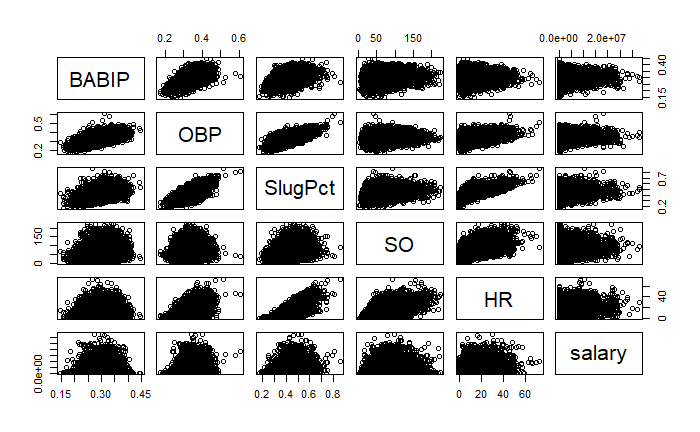

```r
salary_batting_num <- salary_batting%>%
  filter(PA >= 150) %>%
  select(BABIP, OBP, SlugPct, SO, HR, salary)
pairs(salary_batting_num)
```

```r
res1 <- salary_batting_num %>% prcomp(scale = TRUE)
res1
```

```
Standard deviations (1, .., p=6):
[1] 1.7246127 1.1257953 0.9228656 0.7784283 0.4934381 0.2391297

Rotation (n x k) = (6 x 6):
              PC1         PC2         PC3        PC4        PC5         PC6
BABIP   0.3229244  0.61365370 -0.02878539  0.5332141 -0.3750141  0.30556096
OBP     0.4367551  0.44398197  0.17136800 -0.2148811  0.7294642 -0.06682849
SlugPct 0.5166340  0.06041645 -0.09203480 -0.4397030 -0.5020912 -0.52491375
SO      0.3794710 -0.40792052 -0.37520438  0.5999827  0.2536310 -0.35286888
HR      0.4849768 -0.39567425 -0.18691479 -0.2679666 -0.0197219  0.70788928
salary  0.2425973 -0.31575581  0.88635125  0.2106769 -0.1021429 -0.03175417
```

```r
loadings1 <- res1$rotation
loadings1
```

```
              PC1         PC2         PC3        PC4        PC5         PC6
BABIP   0.3229244  0.61365370 -0.02878539  0.5332141 -0.3750141  0.30556096
OBP     0.4367551  0.44398197  0.17136800 -0.2148811  0.7294642 -0.06682849
SlugPct 0.5166340  0.06041645 -0.09203480 -0.4397030 -0.5020912 -0.52491375
SO      0.3794710 -0.40792052 -0.37520438  0.5999827  0.2536310 -0.35286888
HR      0.4849768 -0.39567425 -0.18691479 -0.2679666 -0.0197219  0.70788928
salary  0.2425973 -0.31575581  0.88635125  0.2106769 -0.1021429 -0.03175417
```

```r
score_mat1 <- res1$x
score_mat1
```

```
                   PC1           PC2           PC3           PC4           PC5           PC6
    [1,] -0.0123238066  1.406082e+00  2.548928e-01 -1.274783e+00  0.3041183188 -4.072131e-01
    [2,] -0.1624737053  1.070938e+00 -2.943531e-01  4.588813e-01 -0.3811527169  4.757430e-04
    [3,] -2.5234035659 -7.107483e-01  4.213653e-02 -5.188889e-01  1.0682128779  9.388224e-02
    [4,]  0.9224806779 -1.096691e+00 -9.910050e-01 -5.568136e-01 -0.9600556851 -9.693461e-02
    [5,] -0.2038355666  1.050535e+00  2.076287e-01 -1.183189e+00  0.1775416368 -1.687745e-01
    [6,] -1.0427981961  6.455904e-01 -2.761738e-01  9.388899e-01  0.1830894480 -1.501855e-01
    [7,]  0.4380703914  1.052954e+00 -2.356966e-01 -1.029017e-01  1.1265499421 -1.577050e-03
    [8,]  1.4561225730  2.036814e-01 -7.806643e-01  4.707910e-02 -0.1693297320  4.268268e-01
    [9,]  0.0694390805  2.393435e-01 -7.750837e-02 -1.147511e+00  0.4624617106 -1.356250e-03
   [10,]  2.0956613321 -2.581958e+00 -2.137782e+00  3.469100e-01  0.1154135314  2.058372e-01
   [11,] -5.1139704659 -2.447904e+00  2.546405e-01 -7.765589e-01  0.9452861584  2.782513e-01
   [12,]  3.1347805999  2.188166e-02 -1.549857e+00  6.136689e-01 -0.0390397398 -9.158624e-02
   [13,] -1.1683842200  4.278563e-01 -3.981740e-03 -5.045464e-02  0.6102383410  9.801332e-02
   [14,] -0.2101593431 -4.110821e-01 -5.674888e-01 -5.651232e-01 -0.1885550065  1.868866e-01
```

[output cut: 153 more lines]

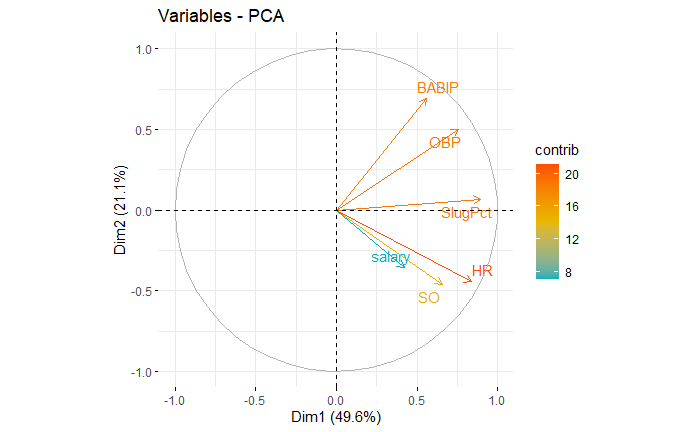

```r
res1 %>%
  fviz_pca_var(axes = c(1,2),
               col.var = "contrib",
               gradient.cols = c("#00AFBB", "#E7B800", "#FC4E07"),
               repel = TRUE
               )
```